# Facial Keypoints detection

# We check one other example that shows that there is lot of error in nose data points

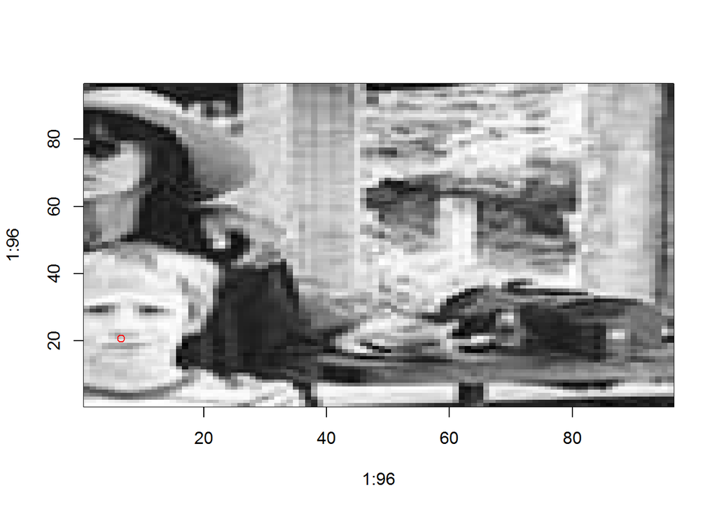

```r
idx <- which.max(training$nose_tip_x)
im  <- matrix(data=rev(im.train[idx,]), nrow=96, ncol=96)
image(1:96, 1:96, im, col=gray((0:255)/255))
points(96-training$nose_tip_x[idx], 96-training$nose_tip_y[idx], col="red")
```

# Building the first estimator - use mean of training set as the predictor for test set

```r
p <- matrix(data=colMeans(training, na.rm=T), nrow=nrow(test), ncol=ncol(training), byrow=T)
colnames(p) <- names(training)
predictions <- data.frame(ImageId = 1:nrow(test), p)
```

# Make csv of all predictions for submission to Kaggle competition

```r
submission <- melt(predictions, id.vars="ImageId", variable.name="FeatureName", value.name="Location")
head(submission)
```

```
##   ImageId       FeatureName Location
## 1       1 left_eye_center_x 66.35902
## 2       2 left_eye_center_x 66.35902
## 3       3 left_eye_center_x 66.35902
## 4       4 left_eye_center_x 66.35902
## 5       5 left_eye_center_x 66.35902
## 6       6 left_eye_center_x 66.35902
```

```r
example.submission <- read.csv('IdLookupTable.csv')
sub.col.names      <- names(example.submission)
example.submission$Location <- NULL
submission <- merge(example.submission, submission, all.x=T, sort=F)
submission <- submission[, sub.col.names]
write.csv(submission, file="submission_means.csv", quote=F, row.names=F)
```

# Using image patches for a better estimator. We use an image patch around left eye center. Patch size is set to 10 pixels

```r
coord      <- "left_eye_center"
patch_size <- 10
search_size <- 2
```

# List the coordinates we have to predict

```r
coordinate.names <- gsub("_x", "", names(training)[grep("_x", names(training))])
coordinate.names
```

```
##  [1] "left_eye_center"         "right_eye_center"
##  [3] "left_eye_inner_corner"   "left_eye_outer_corner"
##  [5] "right_eye_inner_corner"  "right_eye_outer_corner"
##  [7] "left_eyebrow_inner_end"  "left_eyebrow_outer_end"
##  [9] "right_eyebrow_inner_end" "right_eyebrow_outer_end"
## [11] "nose_tip"                "mouth_left_corner"
## [13] "mouth_right_corner"      "mouth_center_top_lip"
## [15] "mouth_center_bottom_lip"
```

# For each one of the above, get the image data into a matrix of 96x96 and then compute the average patch

```r
mean.patches <- foreach(coord = coordinate.names) %dopar%
{
    cat(sprintf("computing mean patch for %s\n", coord))
    coord_x <- paste(coord, "x", sep="_")
    coord_y <- paste(coord, "y", sep="_")

    # compute average patch in training set
    patches <- foreach (i = 1:nrow(training), .combine=rbind) %do%
  {
        im  <- matrix(data = im.train[i,], nrow=96, ncol=96)
        x   <- training[i, coord_x]
        y   <- training[i, coord_y]
        x1  <- (x-patch_size)
        x2  <- (x+patch_size)
        y1  <- (y-patch_size)
        y2  <- (y+patch_size)
        if ( (!is.na(x)) && (!is.na(y)) && (x1>=1) && (x2<=96) && (y1>=1) && (y2<=96) )
        {
            as.vector(im[x1:x2, y1:y2])
        }
        else
        {
            NULL
        }
    }
  matrix(data = colMeans(patches), nrow=2*patch_size+1, ncol=2*patch_size+1)
}
```

```
## computing mean patch for left_eye_center
## computing mean patch for right_eye_center
## computing mean patch for left_eye_inner_corner
## computing mean patch for left_eye_outer_corner
## computing mean patch for right_eye_inner_corner
## computing mean patch for right_eye_outer_corner
## computing mean patch for left_eyebrow_inner_end
## computing mean patch for left_eyebrow_outer_end
## computing mean patch for right_eyebrow_inner_end
## computing mean patch for right_eyebrow_outer_end
## computing mean patch for nose_tip
## computing mean patch for mouth_left_corner
## computing mean patch for mouth_right_corner
## computing mean patch for mouth_center_top_lip
## computing mean patch for mouth_center_bottom_lip
```

# List the coordinates we have to predict

```r
coordinate.names <- gsub("_x", "", names(training)[grep("_x", names(training))])
coordinate.names
```

```
##  [1] "left_eye_center"         "right_eye_center"
##  [3] "left_eye_inner_corner"   "left_eye_outer_corner"
##  [5] "right_eye_inner_corner"  "right_eye_outer_corner"
##  [7] "left_eyebrow_inner_end"  "left_eyebrow_outer_end"
##  [9] "right_eyebrow_inner_end" "right_eyebrow_outer_end"
## [11] "nose_tip"                "mouth_left_corner"
## [13] "mouth_right_corner"      "mouth_center_top_lip"
## [15] "mouth_center_bottom_lip"
```

# For each coordinate and for each test image, find the position in test image that best correlates with the average patch of training images.

```r
p <- foreach(coord_i = 1:length(coordinate.names), .combine=cbind) %dopar%
{
    # the coordinates we want to predict
    coord   <- coordinate.names[coord_i]
    coord_x <- paste(coord, "x", sep="_")
    coord_y <- paste(coord, "y", sep="_")

    # the average of them in the training set (our starting point)
    mean_x  <- mean(training[, coord_x], na.rm=T)
    mean_y  <- mean(training[, coord_y], na.rm=T)

    # search space: 'search_size' pixels centered on the average coordinates
    x1 <- as.integer(mean_x)-search_size
    x2 <- as.integer(mean_x)+search_size
    y1 <- as.integer(mean_y)-search_size
    y2 <- as.integer(mean_y)+search_size

    # ensure we only consider patches completely inside the image
    x1 <- ifelse(x1-patch_size<1,  patch_size+1,  x1)
    y1 <- ifelse(y1-patch_size<1,  patch_size+1,  y1)
    x2 <- ifelse(x2+patch_size>96, 96-patch_size, x2)
    y2 <- ifelse(y2+patch_size>96, 96-patch_size, y2)

    # build a list of all positions to be tested
    params <- expand.grid(x = x1:x2, y = y1:y2)

    # for each image...
    r <- foreach(i = 1:nrow(test), .combine=rbind) %do% {
        if ((coord_i==1)&&((i %% 100)==0)) { cat(sprintf("%d/%d\n", i, nrow(test))) }
        im <- matrix(data = im.test[i,], nrow=96, ncol=96)

        # ... compute a score for each position ...
        r  <- foreach(j = 1:nrow(params), .combine=rbind) %do% {
            x     <- params$x[j]
            y     <- params$y[j]
            p     <- im[(x-patch_size):(x+patch_size), (y-patch_size):(y+patch_size)]
            score <- cor(as.vector(p), as.vector(mean.patches[[coord_i]]))
            score <- ifelse(is.na(score), 0, score)
            data.frame(x, y, score)
        }

        # ... and return the best
        best <- r[which.max(r$score), c("x", "y")]
    }
    names(r) <- c(coord_x, coord_y)
    r
}
```

```
## 100/1783
## 200/1783
## 300/1783
## 400/1783
## 500/1783
## 600/1783
## 700/1783
## 800/1783
## 900/1783
## 1000/1783
## 1100/1783
## 1200/1783
## 1300/1783
## 1400/1783
## 1500/1783
## 1600/1783
## 1700/1783
```

# Prepare file for submission

```r
predictions <- data.frame(ImageId = 1:nrow(test), p)
submission <- melt(predictions, id.vars="ImageId", variable.name="FeatureName", value.name="Location")
example.submission <- read.csv('IdLookupTable.csv')
sub.col.names      <- names(example.submission)
example.submission$Location <- NULL

submission <- merge(example.submission, submission, all.x=T, sort=F)
submission <- submission[, sub.col.names]

write.csv(submission, file="submission_search.csv", quote=F, row.names=F)
```